# Predict house prices - deep learning keras

## Naive model

The naive model is based on the same example in the book by François Chollet with J. J. Allaire

For our first model we will be using the boston housing data from 1970. This data collected features of the sale but had no time index - probably because the data was only collected over 1970; possibly with some cencoring.

With no time index in the data we can think of the tensors as being 1D tensors since the samples have n features on only 1 axis.

With this model we cannot really predict into the future so our predictions are only valid for predicting house prices right now (1970).

### Load the data

```r
dataset <- dataset_boston_housing()
c(c(train_data, train_targets), c(test_data, test_targets)) %<-% dataset
```

The training data we load here is already in a matrix format for us:

```r
train_data %>% head
```

```
##         [,1] [,2]  [,3] [,4]  [,5]  [,6]  [,7]   [,8] [,9] [,10] [,11]
## [1,] 1.23247  0.0  8.14    0 0.538 6.142  91.7 3.9769    4   307  21.0
## [2,] 0.02177 82.5  2.03    0 0.415 7.610  15.7 6.2700    2   348  14.7
## [3,] 4.89822  0.0 18.10    0 0.631 4.970 100.0 1.3325   24   666  20.2
## [4,] 0.03961  0.0  5.19    0 0.515 6.037  34.5 5.9853    5   224  20.2
## [5,] 3.69311  0.0 18.10    0 0.713 6.376  88.4 2.5671   24   666  20.2
## [6,] 0.28392  0.0  7.38    0 0.493 5.708  74.3 4.7211    5   287  19.6
##       [,12] [,13]
## [1,] 396.90 18.72
## [2,] 395.38  3.11
## [3,] 375.52  3.26
## [4,] 396.90  8.01
## [5,] 391.43 14.65
## [6,] 391.13 11.74
```

We have 13 features/dimensions of collected data for each sample that we can use to predict the house price:

```r
train_targets %>% head
```

```
## [1] 15.2 42.3 50.0 21.1 17.7 18.5
```

### Scale the variables

```r
train_data <-
train_data %>%
apply(MARGIN = 1, FUN = scale) %>% t

test_data <-
    test_data %>%
    apply(MARGIN = 1, FUN = scale) %>% t
```

### Define the model

We can start by defining the model. Since we will be using cross-validation we define a function that constructs the model. We do this because we need to construct and train a model on each fold so we can gauge the performance accross the different folds as we fine tune our model:

#### Function that constructs a model

Note that I am assuming the data input is a resample object… That’s because I will be creating a tidy crossvalidation and so the objects in my table will be resamples…

I am also assuming the outcome is called ‘target’, but this can be generalised using enquo

```r
define_compile_train_predict <- function(train,test,epochs = 100,shuffle = TRUE,...){
    # browser()

# train_X <- tidy_cross_val$train[[1]] %>% as_tibble() %>% select(-target) %>% as.matrix()
# test_X <- tidy_cross_val$test[[1]] %>% as_tibble() %>% select(-target) %>% as.matrix()
# train_y <- tidy_cross_val$train[[1]] %>% as_tibble() %>%  select(target) %>% as.matrix()
# test_y <- tidy_cross_val$test[[1]] %>% as_tibble() %>%  select(target) %>% as.matrix()

train_X <- train %>% as_tibble() %>% select(-target) %>% as.matrix()
test_X <- test %>% as_tibble() %>% select(-target) %>% as.matrix()
train_y <- train %>% as_tibble() %>%  select(target) %>% as.matrix()
test_y <- test %>% as_tibble() %>%  select(target) %>% as.matrix()

#define
base_model <-
keras_model_sequential() %>%
layer_dense(units = 64, activation = 'relu', input_shape = c(13)) %>% # 1 axis and nr features = number columns
layer_batch_normalization() %>%
# layer_dropout(rate = 0.2) %>%
layer_dense(units = 64, activation ='relu') %>%
# layer_dense(units = 25, activation ='relu') %>%
layer_dense(units = 1)

#compile
base_model %>% compile(
  loss='mse',
  optimizer='rmsprop',
  metrics = c('mae')
)

#train
history <- base_model %>%
  keras::fit(train_X,
             train_y,
             epochs=epochs,
             shuffle=shuffle,
             validation_data= list(test_X, test_y),
                verbose = 0
             )

#predict
predictions <-
    base_model %>%
    keras::predict_on_batch(x = train_X)

results <-
base_model %>%
evaluate(test_X, test_y, verbose = 0)

plot_outp <-
    history %>% plot

return(list(predictions = predictions, loss = results$loss, mae = results$mean_absolute_error, plot_outp = plot_outp))

}
```

In the example in the book they use a for loop to set up the different folds and then applyt the training and validation inside these loops. Since R has a lot of this already sovled in tidy packages I am just going to leverage them and stay inside of a tidy format so we can keep all the intermediate results and visualize the outputs all in one go

#### Construct tidy cross-validation

To do this we first setup a nice tibble using the modelr package:

```r
tidy_cross_val <-
    train_data %>%
    as_tibble() %>%
    bind_cols(target = train_targets) %>%
    modelr::crossv_kfold(k = 5) %>%
    rename(fold = .id) %>%
    select(fold,everything())

tidy_cross_val
```

```
## # A tibble: 5 x 3
##   fold  train          test
##   <chr> <list>         <list>
## 1 1     <S3: resample> <S3: resample>
## 2 2     <S3: resample> <S3: resample>
## 3 3     <S3: resample> <S3: resample>
## 4 4     <S3: resample> <S3: resample>
## 5 5     <S3: resample> <S3: resample>
```

Now we can build the models and also compile them, after that we just `pluck` out the stuff we stored in our function:

```r
# tidy_cross_val$model_output %>% map_dbl(pluck,"mae")
tidy_cross_val <-
tidy_cross_val %>%
mutate(model_output = pmap(list(train = train,test = test), define_compile_train_predict,epochs = 100)) %>%
mutate(mae = model_output %>% map_dbl(pluck,"mae")) %>%
mutate(plot_outp = model_output %>% map(pluck,"plot_outp")) %>%
mutate(loss = model_output %>% map_dbl(pluck,"loss")) %>%
mutate(predictions = model_output %>% map(pluck,"predictions")) %>%
select(-model_output)

tidy_cross_val
```

```
## # A tibble: 5 x 7
##   fold  train          test             mae plot_outp  loss predictions
##   <chr> <list>         <list>         <dbl> <list>    <dbl> <list>
## 1 1     <S3: resample> <S3: resample>  6.05 <S3: gg>   49.6 <dbl [323 × 1…
## 2 2     <S3: resample> <S3: resample>  4.50 <S3: gg>   39.4 <dbl [323 × 1…
## 3 3     <S3: resample> <S3: resample>  3.10 <S3: gg>   16.6 <dbl [323 × 1…
## 4 4     <S3: resample> <S3: resample>  6.04 <S3: gg>   58.4 <dbl [323 × 1…
## 5 5     <S3: resample> <S3: resample>  4.63 <S3: gg>   45.1 <dbl [324 × 1…
```

From our tidy cross-validation output we may notice some extreme values for folds in terms of high mae or loss…

This could either be outliers or over-fitting or may be bad intialization of weights?

Let’s take a closer look:

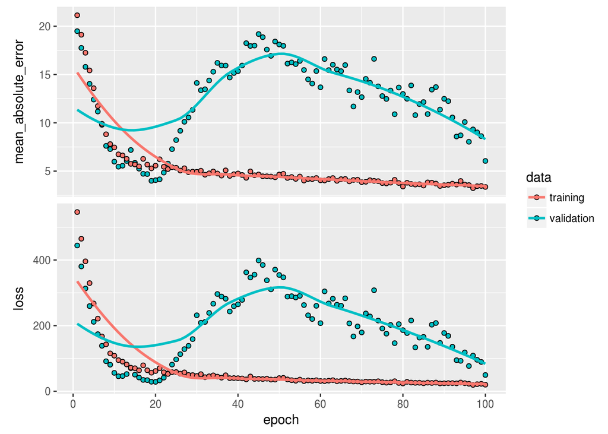

```r
tidy_cross_val %>%
filter(.$mae == max(.$mae)) %>%
pull(plot_outp)
```

We can look at these extreme folds to see if the validation and training loss diverges which should indicate over-fitting

### Get results

Once we are happy with our model we can pull out all the results like this:

```r
tidy_cross_val %>%
select(train,predictions) %>%
mutate(train = train %>% map(as_tibble)) %>%
unnest(.drop = TRUE) %>%
head()
```

```
## # A tibble: 6 x 15
##   predictions     V1     V2     V3     V4     V5     V6      V7     V8
##         <dbl>  <dbl>  <dbl>  <dbl>  <dbl>  <dbl>  <dbl>   <dbl>  <dbl>
## 1        8.76 -0.497 -0.507 -0.444 -0.507 -0.502 -0.460  0.196  -0.476
## 2       28.3  -0.492  0.109 -0.478 -0.492 -0.489 -0.437 -0.378  -0.447
## 3       28.7  -0.444 -0.468 -0.378 -0.468 -0.465 -0.443  0.0311 -0.461
## 4       18.2  -0.455 -0.455 -0.412 -0.455 -0.451 -0.404 -0.166  -0.405
## 5       16.0  -0.453 -0.471 -0.382 -0.471 -0.468 -0.440 -0.0331 -0.458
## 6       12.2  -0.490 -0.492 -0.433 -0.492 -0.488 -0.447  0.0966 -0.454
## # ... with 6 more variables: V9 <dbl>, V10 <dbl>, V11 <dbl>, V12 <dbl>,
## #   V13 <dbl>, target <dbl>
```

But we have only predicted on the training data in our function and we used the model trained only on that fold… Instead it would make a lot more sense to train the model on all the data now that we have tested and tuned the model (possibly censor bad folds?)

## Time series models using LSTM (simple 1 dimensional price in 2D tensor)

### Download the data

Download the data straight from the gov website…

```r
if(!file.exists("static/data/cencus_data.csv")){
    download.file(url = 'https://www.fhfa.gov/DataTools/Downloads/Documents/HPI/HPI_AT_us_and_census.csv',destfile = 'static/data/cencus_data.csv')
}
```

### Read in the data

```r
housing_time_series <-
    data.table::fread(input = "static/data/cencus_data.csv")

housing_time_series %>% head
```

```
##        V1   V2 V3    V4
## 1: DV_ENC 1975  1 63.60
## 2: DV_ENC 1975  2 62.68
## 3: DV_ENC 1975  3 63.57
## 4: DV_ENC 1975  4 64.91
## 5: DV_ENC 1976  1 64.83
## 6: DV_ENC 1976  2 66.85
```

So we can tell that in this data we have primarily just a time index and a value. This is enough for us but we need to pre-process and label these 2 fields in a tidy dataframe before we start ironing out the model process:

```r
housing_time_series %>%
    tidyr::unite(col = index,V2,V3,sep="-") %>%
    mutate(index = index %>% zoo::as.yearqtr() %>% lubridate::as_datetime()) %>%
    rename(price = V4) %>%
    select(-V1)
```

```
##           index  price
## 1    1975-01-01  63.60
## 2    1975-04-01  62.68
## 3    1975-07-01  63.57
## 4    1975-10-01  64.91
## 5    1976-01-01  64.83
## 6    1976-04-01  66.85
## 7    1976-07-01  68.48
## 8    1976-10-01  69.63
## 9    1977-01-01  72.67
## 10   1977-04-01  74.58
## 11   1977-07-01  76.89
## 12   1977-10-01  80.10
## 13   1978-01-01  82.57
## 14   1978-04-01  86.88
```

[output cut: 1706 more lines]